# Enron Email Database R ShinyApp

Charles Manil

2025-05-12

# Loading of the dataset

The pre-processed data set has been provided in the file “Enron.Rdata”. We will first load it in Rstudio in order to retrieve it and work on it.

```r
#Loading of the database. Please replace my_path value with the path of your file. Use a local emplacement to store it, One Drive users may occur errors. Otherwise just access and clone the repo : !!!!
my_path <- "C:/Users/CM_LAPTOP/Downloads/Enron.Rdata"
load(my_path)

# Load required packages
library(dplyr)
```

```r
library(ggplot2)
```

In case you are using the full data set provided on : https://www.cs.cmu.edu/~enron/ , you will then need to extract the .tar.gz with the untar(my_path, exdir=“Your/desired/path) function.

# First step in the Dataset

Let’s gather some information about the different dataframes we retrieved previously.

```r
str(employeelist)
```

```
## 'data.frame':    149 obs. of  9 variables:
##  $ eid      : num  13 6 19 115 129 18 33 149 52 21 ...
##  $ firstName: chr  "Marie" "Mark" "Lindy" "Lisa" ...
##  $ lastName : chr  "Heard" "Taylor" "Donoho" "Gang" ...
##  $ Email_id : chr  "marie.heard@enron.com" "mark.e.taylor@enron.com" "lindy.donoho@enron.com" "lisa.gang@enron.com" ...
##  $ Email2   : chr  "" "mark.taylor@enron.com" "ldonoho@enron.com" "" ...
##  $ Email3   : chr  "" "e.taylor@enron.com" "" "" ...
##  $ EMail4   : chr  "" "" "" "" ...
##  $ folder   : chr  "heard-m" "taylor-m" "donoho-l" "gang-l" ...
##  $ status   : Factor w/ 10 levels "CEO","Director",..: NA 3 3 7 1 2 7 3 3 2 ...
```

```r
str(message)
```

```
## 'data.frame':    252759 obs. of  5 variables:
##  $ mid       : int  52 53 54 55 56 57 58 59 60 61 ...
##  $ sender    : Factor w/ 17527 levels "-persson@ricemail.ricefinancial.com",..: 13252 12358 12358 13252 12358 5565 5088 2900 2868 2361 ...
##  $ date      : Date, format: "2000-01-21" "2000-01-24" ...
##  $ message_id: Factor w/ 252759 levels "<10000282.1075847198841.JavaMail.evans@thyme>",..: 20268 164410 44339 4329 50733 181388 129861 111357 132891 248375 ...
##  $ subject   : chr  "ENRON HOSTS ANNUAL ANALYST CONFERENCE PROVIDES BUSINESS OVERVIEW AND GOALS FOR 2000" "Over $50 -- You made it happen!" "Over $50 -- You made it happen!" "ROAD-SHOW.COM Q4i.COM CHOOSE ENRON TO DELIVER FINANCIAL WEB CONTENT" ...
```

```r
str(recipientinfo)
```

```
## 'data.frame':    2064442 obs. of  4 variables:
##  $ rid   : int  67 68 69 70 71 72 73 74 75 76 ...
##  $ mid   : num  52 53 54 55 56 56 57 58 59 60 ...
##  $ rtype : Factor w/ 3 levels "BCC","CC","TO": 3 3 3 3 3 3 3 3 3 3 ...
##  $ rvalue: Factor w/ 68084 levels "--migrated--sgrendel@ercot.com",..: 2060 2046 2049 2060 2065 18193 10002 56479 54146 63168 ...
```

We do now know that we are against a big data base, related to the emails sent in the company Enron before a major incident. We do have at our disposal an employee list with the different information about the staff, the messages that those users sent via the email vector of communication. The two other tables are information about emails. We do have in the recipientinfo some Ids and the email address of the recipient and in the referenceinfo the link between the recipient and the information contained in the email (the content and the date particularly).

Some simple analysis can be quickly achieved, and with it we will have a better overview of the data.

## Univariate analysis

We will here establish some simple one to one relations that appear in the database, let’s try to focus first on the employee list info.

### Employeelist simple analysis

Let’s try to identify more precisely how the data set is composed in term of employees.

```r
table(employeelist$status)
```

```
##
##               CEO          Director          Employee   In House Lawyer
##                 4                14                41                 1
##           Manager Managing Director               N/A         President
##                14                 3                31                 4
##            Trader    Vice President
##                13                23
```

So it seems that we do have a proper distribution to make clear and precise analysis.

### Temporal analysis of the messages

Lets first create an email_data table that will contain the count of emails monthly.

```r
# Create a data frame with monthly email counts
email_data <- data.frame(
  Date = as.Date(paste0(format(message$date, "%Y-%m"), "-01")),
  Count = 1
)

# Group by Date and summarize the count to see how many email by month
email_data <- email_data %>%
  group_by(Date) %>%
  summarize(Count = sum(Count))

head(email_data)
```

```
## # A tibble: 6 × 2
##   Date       Count
##   <date>     <dbl>
## 1 0001-05-01     2
## 2 0001-06-01     1
## 3 0001-07-01     1
## 4 0001-08-01    12
## 5 0001-09-01     9
## 6 0001-10-01    62
```

We do notice that several of dates are not usable due to some mistakes. We identify that the first one is that 0001 and 0002 are induced instead of 2001 and 2002. We then see a 1979 instead of 1997. For the year 2020, it seems indeed to be an email from 2002. The messages from 2044 and 2043 don’t have records by checking by message ID (mid). As we don’t have the content we will not convert them we will simply remove them.

```r
# Correct errors in the year data in the dataframe
email_data <- email_data %>%
  # Correct years 0001 and 0002 to 2001 and 2002, 1979 to 1997 and 2020 to 2002
  mutate(Date = case_when(
    format(Date, "%Y") == "0001" ~ as.Date(paste0("2001", format(Date, "-%m-%d"))),
    format(Date, "%Y") == "0002" ~ as.Date(paste0("2002", format(Date, "-%m-%d"))),
    format(Date, "%Y") == "1979" ~ as.Date(paste0("1997", format(Date, "-%m-%d"))),
    format(Date, "%Y") == "2020" ~ as.Date(paste0("2002", format(Date, "-%m-%d"))),
    TRUE ~ Date
  ))

# Filtering the data set in order to show only the relevant period (1999 and 2002 in our case)
email_data <- email_data[email_data$Date >= as.Date("1999-01-01") & email_data$Date <= as.Date("2002-12-31"), ]


# Display the data with corrected years
head(email_data)
```

```
## # A tibble: 6 × 2
##   Date       Count
##   <date>     <dbl>
## 1 2001-05-01     2
## 2 2001-06-01     1
## 3 2001-07-01     1
## 4 2001-08-01    12
## 5 2001-09-01     9
## 6 2001-10-01    62
```

```r
# Display summary statistics
summary(email_data)
```

```
##       Date                Count
##  Min.   :1999-01-01   Min.   :    1.0
##  1st Qu.:2000-03-08   1st Qu.:   50.5
##  Median :2001-05-01   Median :  667.0
##  Mean   :2001-01-29   Mean   : 4355.3
##  3rd Qu.:2001-12-01   3rd Qu.: 7435.2
##  Max.   :2002-12-01   Max.   :29556.0
```

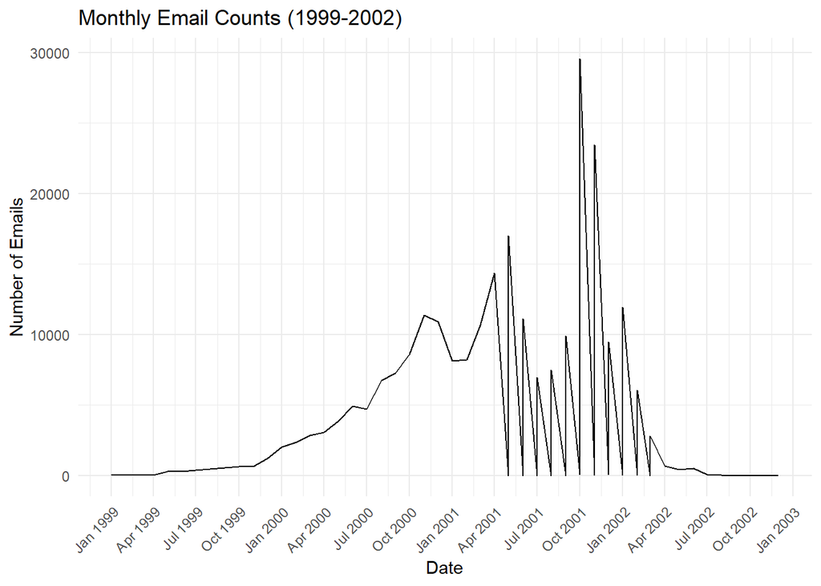

```r
# Create the time series plot
ggplot(email_data, aes(x = Date, y = Count)) +
  geom_line() +
  labs(title = "Monthly Email Counts (1999-2002)",
       x = "Date",
       y = "Number of Emails") +
  theme_minimal() +
  scale_x_date(date_breaks = "3 months", date_labels = "%b %Y") +
  theme(axis.text.x = element_text(angle = 45, hjust = 1))
```

### Most active Email sender

In this part we will focus again on the message data frame. we will try to identify who is the most active email sender of this data set.

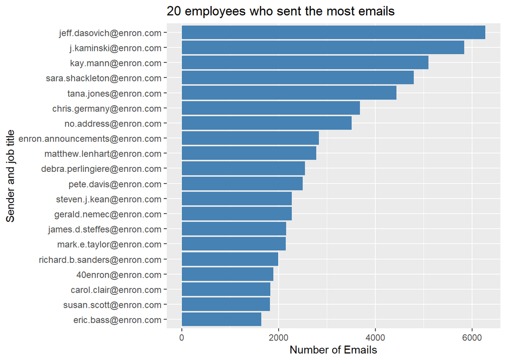

```r
# This part count the number of emails a sender has
top_senders <- message %>%
  count(sender, sort = TRUE) %>%
  slice_max(n, n = 20)  # top 20

# Join the status information with the email address (correspond to the profession of the employee)
top_senders_named <- top_senders %>%
  left_join(employeelist, by = c("sender" = "Email_id")) %>%
  mutate(
    label = ifelse(!is.na(status),
                   paste0(sender, " (", status, ")"),
                   sender)
  )

# Plot this information
ggplot(top_senders_named, aes(x = reorder(sender, n), y = n)) +
  geom_col(fill = "steelblue") +
  coord_flip() +
  labs(
    title = "20 employees who sent the most emails",
    x = "Sender and job title",
    y = "Number of Emails"
  ) +
  theme(axis.text.y = element_text(size = 9))
```